# [6] Skin & Soft Tissue Infection (SSTI): WHO AWaRe QIs analysis against gPPS data

CNPI AMR

Last compiled on Sunday 05 October, 2025

# 📊 Report Overview

This report presents a summary of the AWaRe-based quality indicator analysis based on gPPS inpatient data for Skin & Soft Tissue Infections (SSTI).

This analytical script implements **WHO AWaRe (Access, Watch, Reserve)** antibiotic use **quality indicators (QIs)** for treating **SSTI** in adult inpatients with **community-acquired infections (CAIs)**. It utilises standardised data from the Global PPS (gPPS), specifically extracted from Excel-based outputs received by participating hospitals.

**Skin & Soft Tissue Infections** (Based on WHO AWaRe book)  
▸ **gPPS diagnostic code:** `SST`  
▸ **gPPS definition:** Includes cellulitis, wound infections (including surgical site infections), deep soft tissue not involving bone (e.g., infected pressure ulcers, diabetic ulcers), and abscesses.

The aim is to assess the appropriateness of **empirical antibiotic prescribing** for SSTI, benchmarked against WHO AWaRe Book, and to provide structured feedback at both the hospital and ward levels. These insights support **antimicrobial stewardship efforts** by highlighting patterns of suboptimal prescribing and identifying opportunities for targeted quality improvement.

## 🎯 WHO AWaRe QIs for SSTI

Within the scope of the gPPS data structure, **two** QIs have been identified as compatible for evaluating SSTI-related empirical antibiotic prescriptions in adults with CAIs:

1. **H_SSTI_APPROP_ABX**: Proportion of patients presenting with SSTIs (e.g. necrotizing fascitis or pyomiositis) given the appropriate IV antibiotic according to the WHO AWaRe Book.
2. **H_SSTI_APPROP_DOSAGE**: Proportion of patients presenting with SSTIs (e.g. necrotizing fascitis or pyomiositis) prescribed the recommended total daily dose of IV antibiotics according to the WHO AWaRe Book.

## 💬 General Notes:

- Analysis includes only **adult patients (≥18 years)** with **CAIs** on **empirical** treatment.
- **Intravenous (IV) administration** was inferred using the gPPS `"Route"` code `"P"` (Parenteral), recognizing that it may include other parenteral routes but predominantly indicates IV use in empirical clinical practice.
- It was assumed that **WHO recommendations for SSTI** align with the gPPS diagnostic code **`SST`**; therefore, these cases were assessed using the WHO AWaRe classification.
- **Quality Indicators (QIs)** were mapped and interpreted based on clinical assumptions aligning WHO Book with the available **gPPS diagnostic codes**.

💡 **Reminder:** Caution is advised when interpreting results from small sample sizes (<10 patients)

# 🔍 Initial Data Check

This section assesses whether there are enough eligible cases to support meaningful analysis.

**📅 Survey period:** 01 Feb 2025 to 05 Feb 2025

This script applies **WHO AWaRe Quality Indicators** to adult inpatients who received empirical antibiotics for community-acquired skin and soft tissue infections (CA-SSTIs).

- **Diagnostic code:** SST
- **Total eligible cases:** 5

**⚠️ Caution:** Few eligible cases detected. Interpret results with caution.

# 🧾 Summary of SSTI Eligible Patients for QI Assessment

Eligible patients for **WHO AWaRe QI** assessment are defined as **adult inpatients (≥18 years)** who received **empirical antibiotics** for **CA-SSTI**.

This section presents both **prescription-level** and **patient-level** summaries to establish how much of the dataset is relevant for QI evaluation. It helps frame the proportion of all prescriptions that are relevant to CA-SSTI.

## 👥 Patient-Level Summary

This table reports on unique patients in each eligibility group. It reflects the clinical burden of SSTI and the proportion of patients suitable for QI evaluation.

**📊 Summary:**  
Total number of patients on antibiotics: **205**  
Total number of eligible patients on antibiotics: **5**

| Patient Category | Number of Patients | Proportion of All Patients |
| --- | --- | --- |
| Number of adult patients (≥18 years) who received empirical antibiotic treatment for CAI | 132 | 64.4% |
| Number of all patients with a diagnosis of SSTI on any antibiotics | 5 | 2.4% |
| **Number of eligible patients:** Adult patients (≥18 years) with a diagnosis of CA-SSTI who were treated empirically with antibiotics | 5 | 2.4% |

## 📑 Prescription-Level Summary

**📊 Summary:**  
Total number of antibiotic prescriptions: **215**  
Total number of eligible antibiotic prescriptions: **6**

| Prescription Category | Number of Prescriptions | Proportion of All Prescriptions |
| --- | --- | --- |
| Number of empirical antibiotic prescriptions administered to adult patients (≥18 years) for CAI | 140 | 65.1% |
| Number of all antibiotic prescriptions for patients diagnosed with SSTI | 6 | 2.8% |
| **Number of eligible antibiotic prescriptions:** antibiotics empirically prescribed for adult patients (≥18 years) with CA-SSTI | 6 | 2.8% |

# 📘 WHO AWaRe-QIs Overview

This script evaluates **TWO** WHO AWaRe indicators:

1. **H_SSI_APPROP_ABX**: Proportion of patients presenting with SSTIs (e.g. necrotizing fascitis or pyomiositis) given the appropriate IV antibiotic according to the WHO AWaRe Book.
2. **H_SSI_APPROP_DOSAGE**: Proportion of patients presenting with SSTIs (e.g. necrotizing fascitis or pyomiositis) prescribed the recommended total daily dose of IV antibiotics according to the WHO AWaRe Book.

**🔍 WHO AWaRe Book Recommendation:**

- (**Piperacillin + tazobactam** (4 g + 500 mg q6h IV) COMBINED WITH **Clindamycin** (900 mg q8h IV)) with or without **Vancomycin** (15–20 mg/kg q12h IV)
- (**Ceftriaxone** (2 g q24h IV) COMBINED WITH **Metronidazole** (500 mg q8h IV)) with or without **Vancomycin** (15–20 mg/kg q12h IV)
- **Amoxicillin + clavulanic acid** (1 g + 200 mg q8h IV or 875 mg + 125 mg q8h ORAL)
- **Cefalexin** (500 mg q8h ORAL)
- **Cloxacillin** (2 g q6h IV or 500 mg q6h ORAL)

**🩺 WHO AWaRe Notes:**

- The intravenous route is preferred at least in the first week of treatment
- Step down to oral treatment is based on improvement
- If cloxacillin is unavailable, any other IV antistaphylococcal penicillin could be used.
- For oral administration, dicloxacillin and flucloxacillin are preferred options within the class as they have better oral bioavailability
- Please refer to the WHO AWaRe Antibiotic Book for detailed case-specific recommendations and considerations for different SSIs

# 📌 Indicator 1 – IV Antibiotic Choice Appropriateness

> **H_SSTI_APPROP_ABX:** Proportion of patients presenting with SSTIs (e.g. necrotizing fascitis or pyomiositis) given the appropriate IV antibiotic according to the WHO AWaRe Book.

## 📈 Antibiotic Choice Appropriateness for SSTIs

This visual summarises the proportion of antibiotic appropriateness for SSTI across hospital departments based on WHO AWaRe Book

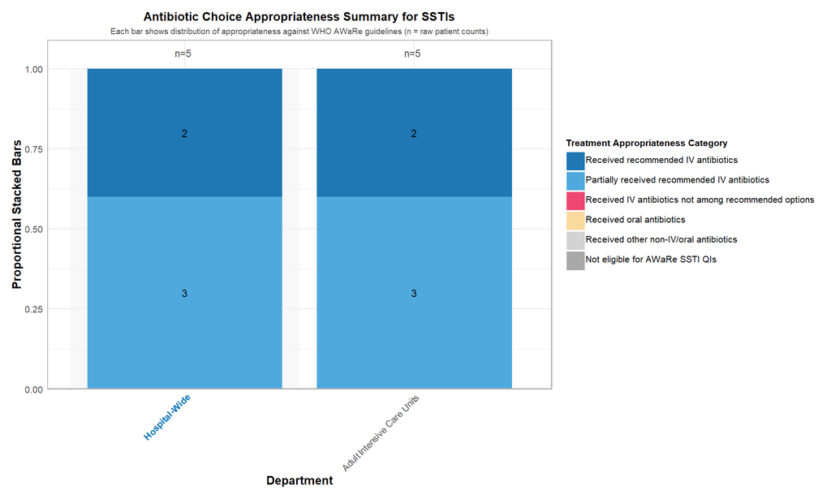

## 📈 Antibiotic Choice Appropriateness by AWaRe Classification

This visual summarises the proportion of antibiotic appropriateness for SSTI across hospital departments by WHO AWaRe Classification (Access, Watch, Reserve)

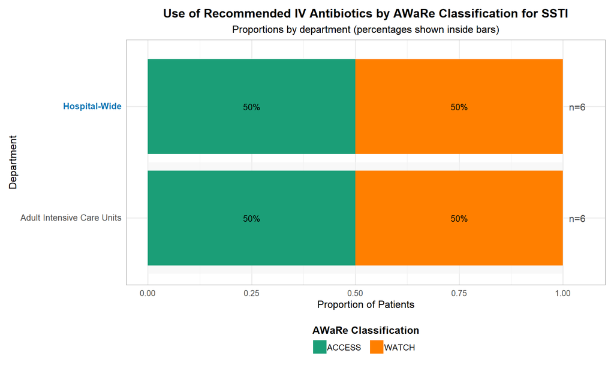

**💡 Note:** The AWaRe classification divides antibiotics into three categories: Access, Watch, and Reserve. Access antibiotics are first-line treatments with a low risk of resistance, typically recommended for common infections. Watch antibiotics are associated with a higher risk of resistance and require careful monitoring. Reserve antibiotics are reserved for critical cases involving resistant infections, typically used only when other options are ineffective .

**💡 Note:** Each patient is counted once per AWaRe category if they received at least one recommended IV antibiotic from that category. Patients treated with recommended antibiotic combinations from multiple categories are included in each, so category totals can exceed the number of unique patients.

## 📝 Summary of Antibiotic Choice Appropriateness for SSTI

This section summarises the proportion of antibiotic choice appropriateness for SSTI across hospital departments based on the WHO AWaRe Book.

💊 **Denominator:** Number of eligible SSTI patients who received any IV antibiotic (**5** out of **5**)

**Summary:**

**🏥 Hospital-Wide** (n = 5 patients)

- ✅ **Received recommended IV antibiotics** (as per WHO AWaRe Book): **40.0%** (2 out of 5)
- ⚠️ **Partially received recommended IV antibiotics** (as per WHO AWaRe Book): **60.0%** (3 out of 5)
- ❌ **Received IV antibiotics not among recommended options** (as per WHO AWaRe Book): **0.0%** (0 out of 5)

**🏥 Adult Intensive Care Units** (n = 5 patients)

- ✅ **Received recommended IV antibiotics** (as per WHO AWaRe Book): **40.0%** (2 out of 5)
- ⚠️ **Partially received recommended IV antibiotics** (as per WHO AWaRe Book): **60.0%** (3 out of 5)
- ❌ **Received IV antibiotics not among recommended options** (as per WHO AWaRe Book): **0.0%** (0 out of 5)

# 💉 Indicator 2 – IV Antibiotic Dosage Appropriateness

> **H_SSTI_APPROP_DOSAGE:** Proportion of patients presenting with SSTIs (e.g. necrotizing fascitis or pyomiositis) prescribed the recommended total daily dose of IV antibiotics according to the WHO AWaRe Book.

## 📈 Antibiotic Choice & Dosage Appropriateness for SSTI

This visual summarises choice & dosage appropriateness for SSTI across hospital departments based on WHO AWaRe Book

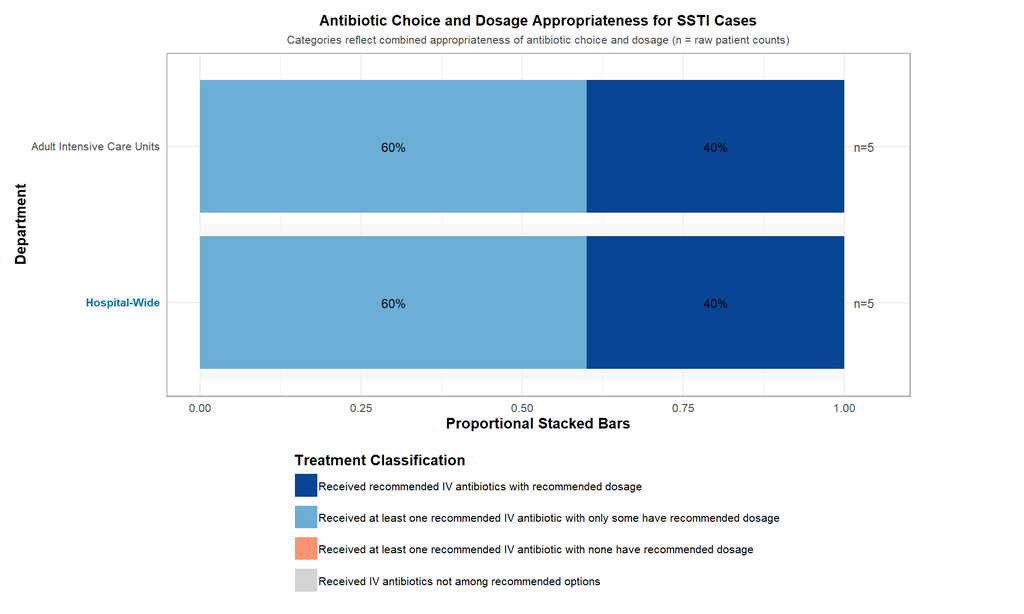

**💡 Notes:**

- **Received recommended IV antibiotics with recommended dosage** indicates that the full recommended treatment regimen (whether monotherapy or dual or triple therapy) was given, with all dosages aligned with WHO AWaRe Book guidance.
- **Received at least one recommended IV antibiotic with some have recommended dosage** refers to cases where only part of the recommended dual or triple therapy was given, and only some antibiotic were at the recommended dosage.
- **Received at least one recommended IV antibiotic with none have recommended dosage** includes cases who received either the full recommended regimen with no recommended dosages, or only part of it (e.g., one agent from a dual therapy) with none of the dosages aligned with WHO AWaRe Book guidance.

## 📝 Summary of Antibiotic Choice & Dosage Appropriateness for SSTI

This section evaluates the **appropriateness of IV antibiotic drug dosage** for patients with CA-SSTI, in line with the WHO AWaRe Book

💊 **Denominator:** Number of eligible SSTI patients who received recommended (*or partially recommended*) IV antibiotic choice based on WHO AWaRe Book (**5**)

**Summary:**

**🏥 Hospital-Wide** (n = 5 patients)

- ✅ **Received recommended IV antibiotics with recommended dosage** (as per WHO AWaRe Book): **40.0%** (2 out of 5)
- ⚠️ **Received at least one recommended IV antibiotic with only some have recommended dosage** (as per WHO AWaRe Book): **60.0%** (3 out of 5)
- ❌ **Received at least one recommended IV antibiotic with none have recommended dosage** (as per WHO AWaRe Book): **0.0%** (0 out of 5)

**🏥 Adult Intensive Care Units** (n = 5 patients)

- ✅ **Received recommended IV antibiotics with recommended dosage** (as per WHO AWaRe Book): **40.0%** (2 out of 5)
- ⚠️ **Received at least one recommended IV antibiotic with only some have recommended dosage** (as per WHO AWaRe Book): **60.0%** (3 out of 5)
- ❌ **Received at least one recommended IV antibiotic with none have recommended dosage** (as per WHO AWaRe Book): **0.0%** (0 out of 5)